# NLP_Capstone_project_sixth

## Machine Learning and AI : May 2019 Batch (Group 10 A)

## IT Suport Tickets Automation : NLP

### Team Members

- Anuj Kumar Agrawal
- Brijesh Kumar
- Girish Kumar
- Seema Malhotra
- Raman Rangasamy

## Case Scenario : Typical Process of IT support process in an IT Service Organization

**IT Support Process :**

- End users (composed of IT Users/ Business Users and Vendor and Supplier (if they have access to IT Support Portal) create IT incidents / tickets using IT Support Portal
- The tickets are automatically assigned to Service Desk.
- Service Desk resolves the L1/L2 tickets
- If Service Desk is unable to solve the tickets (L3 tickets), they assign the L3 tickets to Functional and IT Experts.
- Functional / IT Experts resolves the L3 tickets. If required, external vendor’s help is taken for L3 tickets resolution
- L3 tickets/ priority tickets can be directly assigned to Functional experts in case of urgency via phone calls/ e-mails etc.

**Volumes being Handled :**

- ~ 54% of L1/L2 tickets are handled and resolved by Service Desk
- ~56% of L3 tickets are handled and resolved by Functional/ IT Experts/ Vendors (as per requirements)

**Time Spent:**

- 15 min is being spent for SOP review for each incident
- Minimum ~25-30% of incidents needs to be reviewed for SOPs before ticket assignment
- Minimum of ~1 FTE effort needed “only “for incident assignment to L3 teams.

**Others:**

- Around ~25% of Incidents are wrongly assigned to functional teams
- Delay in ticket resolution impacting the business
- Additional FTEs required for L1/L2 support and correct assignment of tickets
- User dissatisfaction
- Under-utilization of resources because of non-value added activities

**Objective:**

- To reduce the ticket assignment time
- To reduce ticket resolution time
- To reduce wrong assignment of tickets
- To optimize the resources

e.g. Service Desk can utilize the time for ticket resolution instead of going through SOP and ticket assignment

ML/AI can work 24X7 through out the year (without worrying about corona )

**Proposal :**

To automate the ticket the process of ticket analysis and assignment to the right functional / IT expert groups (using Machine Learning / AI tool)

### *Import Libraries required for the Project*

```python
# Let us first start with the special packages we are likely

import numpy as np
import pandas as pd
import matplotlib.pyplot as plt
import seaborn as sns
%matplotlib inline
import os
import pickle

import re
from pprint import pprint

# For textprocessing and and related stuff
import gensim
import gensim.corpora as corpora
from gensim.utils import simple_preprocess
from gensim.models import CoherenceModel
from gensim import corpora, models

import nltk
from nltk.corpus import wordnet
from nltk.stem import WordNetLemmatizer
from nltk.corpus import stopwords

# spacy for lemmatization
import spacy

# Plotting tools
import pyLDAvis
import pyLDAvis.gensim
from wordcloud import WordCloud, STOPWORDS
import matplotlib.colors as mcolors

# Algorithms and accuracy evaluation
from sklearn.metrics import confusion_matrix
from sklearn import metrics
from sklearn.metrics import roc_auc_score
from sklearn.metrics import classification_report
from sklearn.linear_model import LogisticRegression
from sklearn.tree import DecisionTreeClassifier
from sklearn.ensemble import RandomForestClassifier
from sklearn.ensemble import AdaBoostClassifier
from sklearn.ensemble import BaggingClassifier
from sklearn.ensemble import GradientBoostingClassifier
from sklearn.naive_bayes import MultinomialNB
from sklearn import svm
from sklearn.model_selection import cross_val_score
from sklearn.preprocessing import LabelBinarizer

## For Dep Learning and Neural Network
from tensorflow.keras.preprocessing.text import Tokenizer
from tensorflow.keras.preprocessing.sequence import pad_sequences
from keras.utils.np_utils import to_categorical

from keras.layers import LSTM, Activation, Dense, Dropout, Input, Embedding
from keras.optimizers import RMSprop
from keras.models import Sequential
from keras.layers import Dense, Embedding, LSTM, SpatialDropout1D,Bidirectional,Flatten,TimeDistributed
from keras.layers import GlobalMaxPool1D,GlobalAveragePooling1D



# Enable logging for gensim
import logging
logging.basicConfig(format='%(asctime)s : %(levelname)s : %(message)s', level=logging.ERROR)

import warnings
warnings.filterwarnings("ignore",category=DeprecationWarning)
# import warnings filter

from warnings import simplefilter
# ignore all future warnings
simplefilter(action='ignore', category=FutureWarning)

import warnings
warnings.filterwarnings('ignore')
```

### *Reading and exploring the data set*

```python
df = pd.read_excel("ticket_data.xlsx")
```

Let us look some of the rows to see if we could read the dataset properly

```python
# First 10 rows
df.head(10)
```

|  | Short description | Description | Caller | Assignment group |
| --- | --- | --- | --- | --- |
| 0 | login issue | -verified user details.(employee# & manager na... | spxjnwir pjlcoqds | GRP_0 |
| 1 | outlook | \r\n\r\nreceived from: hmjdrvpb.komuaywn@gmail... | hmjdrvpb komuaywn | GRP_0 |
| 2 | cant log in to vpn | \r\n\r\nreceived from: eylqgodm.ybqkwiam@gmail... | eylqgodm ybqkwiam | GRP_0 |
| 3 | unable to access hr_tool page | unable to access hr_tool page | xbkucsvz gcpydteq | GRP_0 |
| 4 | skype error | skype error | owlgqjme qhcozdfx | GRP_0 |
| 5 | unable to log in to engineering tool and skype | unable to log in to engineering tool and skype | eflahbxn ltdgrvkz | GRP_0 |
| 6 | event: critical:HostName_221.company.com the v... | event: critical:HostName_221.company.com the v... | jyoqwxhz clhxsoqy | GRP_1 |
| 7 | ticket_no1550391- employment status - new non-... | ticket_no1550391- employment status - new non-... | eqzibjhw ymebpoih | GRP_0 |
| 8 | unable to disable add ins on outlook | unable to disable add ins on outlook | mdbegvct dbvichlg | GRP_0 |
| 9 | ticket update on inplant_874773 | ticket update on inplant_874773 | fumkcsji sarmtlhy | GRP_0 |

```python
# last 10 rows
df.tail(10)
```

|  | Short description | Description | Caller | Assignment group |
| --- | --- | --- | --- | --- |
| 8490 | check status in purchasing | please contact ed pasgryowski (pasgryo) about ... | mpihysnw wrctgoan | GRP_29 |
| 8491 | vpn for laptop | \n\nreceived from: jxgobwrm.qkugdipo@gmail.com... | jxgobwrm qkugdipo | GRP_34 |
| 8492 | hr_tool etime option not visitble | hr_tool etime option not visitble | tmopbken ibzougsd | GRP_0 |
| 8493 | erp fi - ob09, two accounts to be added | i am sorry, i have another two accounts that n... | ipwjorsc uboapexr | GRP_10 |
| 8494 | tablet needs reimaged due to multiple issues w... | tablet needs reimaged due to multiple issues w... | cpmaidhj elbaqmtp | GRP_3 |
| 8495 | emails not coming in from zz mail | \r\n\r\nreceived from: avglmrts.vhqmtiua@gmail... | avglmrts vhqmtiua | GRP_29 |
| 8496 | telephony_software issue | telephony_software issue | rbozivdq gmlhrtvp | GRP_0 |
| 8497 | vip2: windows password reset for tifpdchb pedx... | vip2: windows password reset for tifpdchb pedx... | oybwdsgx oxyhwrfz | GRP_0 |
| 8498 | machine não está funcionando | i am unable to access the machine utilities to... | ufawcgob aowhxjky | GRP_62 |
| 8499 | an mehreren pc`s lassen sich verschiedene prgr... | an mehreren pc`s lassen sich verschiedene prgr... | kqvbrspl jyzoklfx | GRP_49 |

```python
print(df.dtypes)
print(df.shape)
```

```
Short description    object
Description          object
Caller               object
Assignment group     object
dtype: object
(8500, 4)
```

Data Descrption :

```
- Short description          object  *This is a shrt description of the issue/ problem (tickets)*
- Description                object  *This gives more detailed description of the tickets*
- Caller                     object  *This is the user caller who reported the issue*
- Assignment group           object  *This is the group to which the tickes has been assigned for resolution*
```

Shape of the data

```
- No of rows    = 8500
- No of columns = 4
```

```
[Text(0, 0.5, 'Percent')]
```

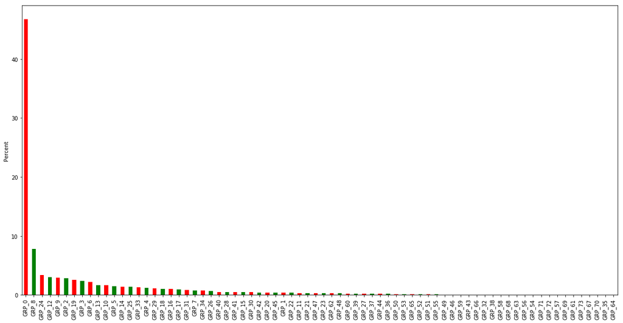

```python
ax = (df['Assignment group'].value_counts(normalize=True, sort=True)*100).plot(kind = 'bar',figsize=(20,10),color=list('rg'))
ax.set(ylabel="Percent")
```

**Observations**

*Data is highly imbalanced based on Assigment Groups*

*There will not be a good learning/ Training for all the Assignment groups becuase of very less observation for many of the groups*

- **We tried out NLP model using LSTM models (Deep Learning with Optimization) and other classifiers with 74 assignment group.** .

*(Similar steps as we'll showing now for final version)*

- *The maximum accuaracy level reached was about 65% after Text cleaning and Preprocessing for "Short Description". Accuracy level ranged between 45-65%*

*Now we if compare the situation , the exsiting error in assignemnt is about 25%* *AND *about 30-35% error rate with AiOps , 74 groups, it DOES NOT MAKE ANY SENSE.*

*WE'LL HAVE TO FIND OUT SOME OTHER SCINTIFIC WAY TO DO THIS. WE'LL MAKE A PROPOSAL NOW TO HANDLE THIS IN OUR FINAL VERSION*

## Data Preprocessing :

```python
df.notnull().sum()
```

```
Short description    8492
Description          8499
Caller               8500
Assignment group     8500
dtype: int64
```

**As we can see, there are some NULL values in columns, Short Description and Description (max. 8 rows). As these are ot many, we'l drop the observations with NULL values for further analysis**

```python
df['new_desc'] = df['Short description']
```

```python
df = df[df['new_desc'].notnull()]
```

## Text Preprocessing :

Before we start working on any of the Machine Learning / Depp Learning / Natural Language processing, there are some general step we should follow to clean the text data. General Steps are:

- Convert the text to lower case
- Remove digits, punctuation marks, new line , carriage return and unwanted spaces
- Remove stop words (stop words are words which are filtered out before or after processing of natural language data. Though "stop words" usually refers to the most common words in a language, there is no single universal list of stop words)
- Tokenization, Stemming and Lemmatization

For grammatical reasons, documents use different forms of a word, such as organize, organizes, and organizing. Additionally, there are families of derivationally related words with similar meanings, such as democracy, democratic, and democratization. In many situations, it seems as if it would be useful for a search for one of these words to return documents that contain another word in the set.

The goal of both stemming and lemmatization is to reduce inflectional forms and sometimes derivationally related forms of a word to a common base form. For instance:

am, are, is => be car, cars, car's, cars' $\Rightarrow$ car The result of this mapping of text will be something like: the boy's cars are different colors $\Rightarrow$ the boy car be differ color

- Stemming usually refers to a crude process that chops off the ends of words in the hope of achieving this goal correctly most of the time, and often includes the removal of derivational affixes.
- Lemmatization usually refers to doing things properly with the use of a vocabulary and morphological analysis of words, to return the base or dictionary form of a word, which is known as the lemma . (We'll not use Stemming but Lemmatization for our project assignment)
- Tokenization is the task of chopping up a sentence into pieces, called tokens , perhaps at the same time throwing away certain characters, such as punctuation. Here is an example of tokenization:

Input: Friends, Romans, Countrymen, lend me your ears;

Output: [Friends][Romans][Countrymen][lend][me][your][ears]

```python
def clean_unwanted_words(doc_text):

    # Convert to list
    documents = doc_text

    documents = [sent.lower() for sent in documents]

    # Remove Emails
    documents = [re.sub('\S*@\S*\s?', '', sent) for sent in documents]

    # Remove new line characters
    documents = [re.sub('\s+', ' ', sent) for sent in documents]

    # Remove distracting single quotes
    documents = [re.sub("\'", "", sent) for sent in documents]
    return(documents)

# simple_preprocess tokenizes the sentence .
# When we set the flag deacc=True , the function removes punctuations also
def sent_to_words(sentences):
    for sentence in sentences:
        yield(gensim.utils.simple_preprocess(str(sentence), deacc=True))  # deacc=True removes punctuations

# Define functions for stopwords, bigrams, trigrams and lemmatization
def remove_stopwords(texts):
    return [[word for word in simple_preprocess(str(doc)) if word not in stop_words] for doc in texts]

def get_wordnet_pos(word):
    """Map POS tag to first character lemmatize() accepts"""
    tag = nltk.pos_tag([word])[0][1][0].upper()
    tag_dict = {"J": wordnet.ADJ,
                "N": wordnet.NOUN,
                "V": wordnet.VERB,
                "R": wordnet.ADV}

    return tag_dict.get(tag, wordnet.NOUN)

stop_words = stopwords.words('english')
stop_words.extend(['from', 'subject', 're', 'edu', 'use', 'received'])
```

```python
def preprocess_text(text):
    documents      = clean_unwanted_words(text)
    document_words = list(sent_to_words(documents))
    document_words = remove_stopwords(document_words)

    # Init Lemmatizer
    lemmatizer = WordNetLemmatizer()
    hl_lemmatized = []
    for tokens in document_words:
        lemm = [lemmatizer.lemmatize(w, get_wordnet_pos(w)) for w in tokens]
        hl_lemmatized.append(lemm)

    processed_txt = hl_lemmatized
    return(processed_txt)

processed_docs = preprocess_text(df['new_desc'])

print('Text preprocessing completed ..')
```

```
Text preprocessing completed ..
```

```python
# Creating a dictionary of words
dictionary = gensim.corpora.Dictionary(processed_docs)
print("Checking few word of my dictionary")
count = 0
for k, v in dictionary.iteritems():
    print(k, v)
    count += 1
    if count > 10:
        break
print("Looks good. Our dictionary is created ..")
print("No. of words in our dictionary are : ", len(dictionary))
```

```
Checking few word of my dictionary
0 issue
1 login
2 outlook
3 cant
4 log
5 vpn
6 access
7 hr_tool
8 page
9 unable
10 error
Looks good. Our dictionary is created ..
No. of words in our dictionary are :  5333
```

## Topic Modeling and Feature Extraction

### Why Topic Modeling ?

**The first question is what is topic modelling and why we want this ?**.

**As we have seen previusly that with 74 groups , we could not really justify a model which can be used to AUTOMATICALLY assign the tickets to a group with accuracy better than the current ITSP process. Manual trial and error of regrouping didn't help either.**

*So we require a better and statistical way to restruture the assignment groups. That is where Topics Modelling comes into the picture to help us

- Topic modeling is a machine learning technique that automatically analyzes text data to determine cluster words for a set of documents. This is known as ‘unsupervised’ machine learning because it doesn’t require a predefined list of tags or training data that’s been previously classified by humans.
- Topic modeling involves counting words and grouping similar word patterns to infer topics within unstructured data. Instead of spending hours going through heaps of text feedback, in an attempt to deduce which texts are talking about our topics of interest, we could analyze them with a topic modeling algorithm.
- Topic modeling algorithms churn out collections of expressions and words that it thinks are related, leaving US to figure out what these relations means
- By detecting patterns such as word frequency and distance between words, a topic model clusters feedback that is similar, and words and expressions that appear most often. With this information, you can quickly deduce what each set of texts are talking about.

*So for or project, we'll assume that whatever text data we have is NOT LABELLED and we'll use topic modelling to create the labels for us (WHICH CAN BE TREATED AS NEW ASSIGNMENT GROUP*

##### We'll use Latent Dirichlet Allocation (LDA) modelling technique classify text in a document (data sets).

##### It will build a topic per document model and words per topic model, modeled as Dirichlet distributions.

##### FEATURE EXTRACTION

**Need of feature extraction techniques** The main problem in working with language processing is that machine learning algorithms cannot work on the raw text directly. So, we need some feature extraction techniques to convert text into a matrix(or vector) of features. Some of the most popular methods of feature extraction are :

- Bag-of-Words
- TF-IDF

**Bag of Words:** Bag-of-Words is one of the most fundamental methods to transform tokens into a set of features. The BoW model is used in document classification, where each word is used as a feature for training the classifier. We'll also use Bag-of-words for feature extraction and for LDA. We'll also use TF-IDF to validate the LDA of Bag-of-words

```python
# Let us create the corpus  (Bag of words which gives the word an the frequency of occurence for each document)
bow_corpus = [dictionary.doc2bow(doc) for doc in processed_docs]
# Let us also ceate Tf-IDF vectors (features)F
tfidf = models.TfidfModel(bow_corpus)
tfidf_corpus = tfidf[bow_corpus]
```

```python
## Let us create functioon for LDA . We will use it for both Bag-of-word and TFIDF
def generate_lda_model(input_corpus):
    lda_model = gensim.models.ldamodel.LdaModel(corpus= input_corpus,
                                               id2word=dictionary,
                                               num_topics=4,      ## We tried different values for this hyperparameter
                                               random_state=100,
                                               update_every=1,
                                               chunksize=100,
                                               passes=10,
                                               alpha='auto',
                                               per_word_topics=True)
    return(lda_model)

# The fucntion will be used to display word cloud
def disp_word_cloud(lda_model):

    cols = [color for name, color in mcolors.TABLEAU_COLORS.items()]  # more colors: 'mcolors.XKCD_COLORS'

    cloud = WordCloud(stopwords=stop_words,
                  background_color='black',
                  width=2500,
                  height=1800,
                  max_words=10,
                  colormap='tab10',
                  color_func=lambda *args, **kwargs: cols[i],
                  prefer_horizontal=1.0)

    topics = lda_model.show_topics(formatted=False)
    #topics = lda_model_tfidf.show_topics(formatted=False)

    fig, axes = plt.subplots(2, 2, figsize=(12,12), sharex=True, sharey=True)

    for i, ax in enumerate(axes.flatten()):
        fig.add_subplot(ax)
        topic_words = dict(topics[i][1])
        cloud.generate_from_frequencies(topic_words, max_font_size=300)
        plt.gca().imshow(cloud)
        plt.gca().set_title('Topic ' + str(i), fontdict=dict(size=16))
        plt.gca().axis('off')


    plt.subplots_adjust(wspace=0, hspace=0)
    plt.axis('off')
    plt.margins(x=0, y=0)
    plt.tight_layout()
    plt.show()

    return
```

```python
print("Creating LDA model based on Bag-of_words ..")
lda_model_bow   = generate_lda_model(bow_corpus)
print("Creating LDA model based on TF-IDF ..")
lda_model_tfidf = generate_lda_model(tfidf_corpus)
print("LDA Models created ")
```

```
Creating LDA model based on Bag-of_words ..
Creating LDA model based on TF-IDF ..
LDA Models created
```

Something has been done by LDA.

Let us see what it has done for us.

It may take some time to generate the visalization.

**Let us be patient as the end result is going to be very interesting** ** Starting with LDA model based on Bag-of-words corpus"

```python
# Visualize the topics
pyLDAvis.enable_notebook()
vis = pyLDAvis.gensim.prepare(lda_model_bow, bow_corpus, dictionary)
vis
```

[interactive chart not shown]

**Looks interesting . We'll provide the interpretation in few minutes**

**Let us see what LDA model with TF-IDF gives us. Again , we have to be patient for the end result**

```python
pyLDAvis.enable_notebook()
vis = pyLDAvis.gensim.prepare(lda_model_tfidf, tfidf_corpus, dictionary)
vis
```

[interactive chart not shown]

**Interpretation of LDA Model**

For both Bag-of-words and TF-IDF corpus, we can see some circle/bubbles (4 in our case) and on the right side a bar graph.

- Number if Circled define the group/ topics (which we have given as an input parameter and which is a hyperparameter also)
- The lesser is the intersection between the circles the better it is for us. No intersection is a boon If the distinctive circles are far apart (distance between the circles), it is an icing on the cake.
- What it indicates is that we based on the corpus, we can have 4 DISTINCT Topics  
  If the circles are overlapping , we don't have really distinct topics based on the corpus.

That is the reason we play around with diffrent values of num_topics parameter (3-15) and we got the best result with num_topics = 4

- The bar chart on the right provides the 30 top words in a topic. If we click on any circle we'll see the result changing on right side (red color) Blue colour provides overall term frequency under the topic and red colur provides the estimated frequeny within the selected topic.

Here also we'll see a very good aount of overlap / fit

Also both the LDA model (with Bag-of-words and TF-IDF) gives similar results which gives us the confidence that the topics created can really be generalized for our modelling

##### Now let us look at another visualizaton to see the topics. This will start giving us the idea about the related topics based on the words

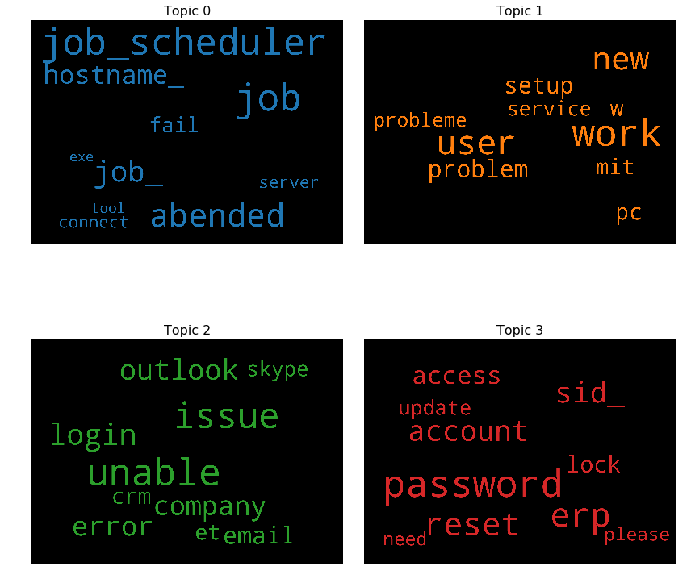

```python
disp_word_cloud(lda_model_bow)
```

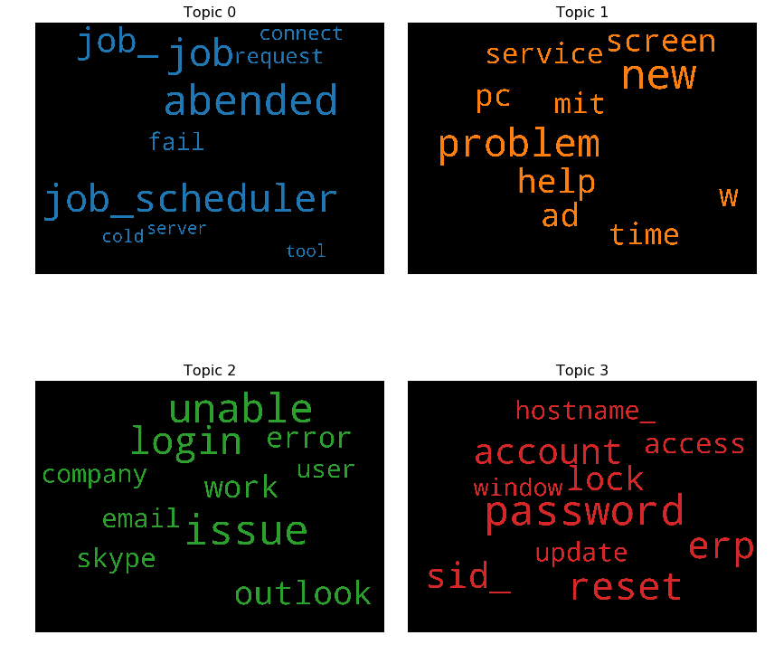

```python
disp_word_cloud(lda_model_tfidf)
```

##### Interpretation :

If we look at the work cloud (we have done it for both Bag-of-words and TF-IDF). We can not only see the distinct group (provided by LDA) but also we can make good guess about the group call as well. e.g.

- topic 0: seems to be related to problems about background jobs, status, issues etc.
- topic 1 :seems to be related to general problems about user pcs (e.g. setup, services etc.)
- topic 2 :seems to be related to problems about communication problems (e.g. outlook, email, skype etc.)
- topic 3 :seem to be realted to the problems arising out of applications (erp, crmm password reset locked etc.)

We are on the good way now.

## Create new dataset based on the New Group

Now as we have for groups coming out of topic modelling , our objective now is to label the documents with the labels(4 groups now). Once done, we'll start oue model creation based on the new groups (0,1,2 and 3)

```python
## function to create dominannt group based on the document text

def format_topics_sentences(ldamodel=None, corpus=None, texts=None):
    # Init output
    sent_topics_df = pd.DataFrame()

    # Get main topic in each document
    for i, row_list in enumerate(ldamodel[corpus]):
        row = row_list[0] if ldamodel.per_word_topics else row_list
        row = sorted(row, key=lambda x: (x[1]), reverse=True)

        # Get the Dominant topic, Perc Contribution and Keywords for each document
        for j, (topic_num, prop_topic) in enumerate(row):
            if j == 0:           # => This will be the dominant topic
                wp = ldamodel.show_topic(topic_num)
                topic_keywords = ", ".join([word for word, prop in wp])
                sent_topics_df = sent_topics_df.append(pd.Series([str(topic_num), round(prop_topic,4), topic_keywords]), ignore_index=True)
            else:
                break
    sent_topics_df.columns = ['Dominant_Group', 'Perc_Contribution', 'Topic_Keywords']
    # Add original text to the end of the output
    contents = pd.Series(texts)
    sent_topics_df = pd.concat([sent_topics_df, contents], axis=1)
    return(sent_topics_df)
```

```python
# re-crate the dataframe to check
df_topic_sents_keywords = format_topics_sentences(ldamodel=lda_model_bow, corpus=bow_corpus, texts=processed_docs)
# Format
df_dominant_topic = df_topic_sents_keywords.reset_index()
df_dominant_topic.columns = ['Document_No', 'Dominant_Group', 'Topic_Perc_Contrib', 'Keywords', 'Text']
df_dominant_topic.head(20)
```

|  | Document_No | Dominant_Group | Topic_Perc_Contrib | Keywords | Text |
| --- | --- | --- | --- | --- | --- |
| 0 | 0 | 2 | 0.7501 | unable, issue, login, outlook, error, company,... | [login, issue] |
| 1 | 1 | 2 | 0.6367 | unable, issue, login, outlook, error, company,... | [outlook] |
| 2 | 2 | 2 | 0.5716 | unable, issue, login, outlook, error, company,... | [cant, log, vpn] |
| 3 | 3 | 2 | 0.4619 | unable, issue, login, outlook, error, company,... | [unable, access, hr_tool, page] |
| 4 | 4 | 2 | 0.7501 | unable, issue, login, outlook, error, company,... | [skype, error] |
| 5 | 5 | 2 | 0.3874 | unable, issue, login, outlook, error, company,... | [unable, log, engineering, tool, skype] |
| 6 | 6 | 0 | 0.3299 | job, job_scheduler, abended, job_, hostname_, ... | [event, critical, hostname_, company, com, val... |
| 7 | 7 | 1 | 0.6099 | work, user, new, problem, setup, pc, mit, w, s... | [ticket_no, employment, status, new, non, empl... |
| 8 | 8 | 2 | 0.6555 | unable, issue, login, outlook, error, company,... | [unable, disable, add, in, outlook] |
| 9 | 9 | 3 | 0.7990 | password, erp, reset, sid_, account, access, l... | [ticket, update, inplant_] |
| 10 | 10 | 0 | 0.3934 | job, job_scheduler, abended, job_, hostname_, ... | [engineering, tool, say, connect, unable, subm... |
| 11 | 11 | 2 | 0.3901 | unable, issue, login, outlook, error, company,... | [hr_tool, site, load, page, correctly] |
| 12 | 12 | 2 | 0.6488 | unable, issue, login, outlook, error, company,... | [unable, login, hr_tool, sgxqsuojr, xwbesorf, ... |
| 13 | 13 | 3 | 0.4538 | password, erp, reset, sid_, account, access, l... | [user, want, reset, password] |
| 14 | 14 | 2 | 0.8035 | unable, issue, login, outlook, error, company,... | [unable, open, payslip] |
| 15 | 15 | 3 | 0.7990 | password, erp, reset, sid_, account, access, l... | [ticket, update, inplant_] |
| 16 | 16 | 2 | 0.8461 | unable, issue, login, outlook, error, company,... | [unable, login, company, vpn] |
| 17 | 17 | 1 | 0.6549 | work, user, new, problem, setup, pc, mit, w, s... | [undock, pc, screen, come, back] |
| 18 | 18 | 3 | 0.8376 | password, erp, reset, sid_, account, access, l... | [erp, sid_, account, lock] |
| 19 | 19 | 2 | 0.5718 | unable, issue, login, outlook, error, company,... | [unable, sign, vpn] |

**Interpretation** We can see the original text column and document numbers Based on the keywords for each group (each keyword has some weight in the group, the text words are evaluated for and we get the percent ontribution of the topic. Based on the Topic probability the most dominant group is assigned to the document.

This is for understanding as to how the new group assigments are taking place.

In following few code liness, what we are doing is to combine informations from different dataframes, to make single dataframe with difefrent columns.

- This will also help us to create a type of relation ship of each document with old assignment group ans new assignment group) If the go ahae is given to implement the model, we can suggest as to how the old assignment groups can be assigned to nee groups (from 74 to 4) rather than hit and trial.

```python
df_dominant_topic['Dominant_Group']=df_dominant_topic['Dominant_Group'].astype('category')
```

```python
text_orig= df_dominant_topic['Text']
```

```python
# Make sentences out of clean words
clean_sent_col = ["Document_No","Clean_text"]
clean_sent_df  = pd.DataFrame(columns=clean_sent_col)
#pd.DataFrame(columns = clean_sent_col)

doc = 0
for doc in range(len(text_orig)):
    sentence = ""
    for word in text_orig[doc]:
        sentence += " " + word
    df_entry =  pd.DataFrame([[doc,sentence]], columns = clean_sent_col)
    clean_sent_df = clean_sent_df.append(df_entry)
clean_sent_df['Assignment group'] = df['Assignment group']
clean_sent_df.head(10)
```

|  | Document_No | Clean_text | Assignment group |
| --- | --- | --- | --- |
| 0 | 0 | login issue | GRP_0 |
| 0 | 1 | outlook | GRP_0 |
| 0 | 2 | cant log vpn | GRP_0 |
| 0 | 3 | unable access hr_tool page | GRP_0 |
| 0 | 4 | skype error | GRP_0 |
| 0 | 5 | unable log engineering tool skype | GRP_0 |
| 0 | 6 | event critical hostname_ company com value mo... | GRP_0 |
| 0 | 7 | ticket_no employment status new non employee ... | GRP_0 |
| 0 | 8 | unable disable add in outlook | GRP_0 |
| 0 | 9 | ticket update inplant_ | GRP_0 |

```python
df_temp = pd.merge(df_dominant_topic, clean_sent_df, how='left', on='Document_No')
df_temp.head()
```

|  | Document_No | Dominant_Group | Topic_Perc_Contrib | Keywords | Text | Clean_text | Assignment group |
| --- | --- | --- | --- | --- | --- | --- | --- |
| 0 | 0 | 2 | 0.7501 | unable, issue, login, outlook, error, company,... | [login, issue] | login issue | GRP_0 |
| 1 | 1 | 2 | 0.6367 | unable, issue, login, outlook, error, company,... | [outlook] | outlook | GRP_0 |
| 2 | 2 | 2 | 0.5716 | unable, issue, login, outlook, error, company,... | [cant, log, vpn] | cant log vpn | GRP_0 |
| 3 | 3 | 2 | 0.4619 | unable, issue, login, outlook, error, company,... | [unable, access, hr_tool, page] | unable access hr_tool page | GRP_0 |
| 4 | 4 | 2 | 0.7501 | unable, issue, login, outlook, error, company,... | [skype, error] | skype error | GRP_0 |

Here we get the final dataframe for modelling. We'll keep only important columns (mainly document text and group/ labels)

```python
#df_temp.to_excel (r'export_dataframe.xlsx', index = False, header=True)
```

```python
df_final =  df_temp.drop(['Topic_Perc_Contrib', 'Keywords', 'Text'], axis = 1)
```

```python
df_final.groupby("Dominant_Group").count()
```

| Dominant_Group | Document_No | Clean_text | Assignment group |
| --- | --- | --- | --- |
| 0 | 1465 | 1465 | 1465 |
| 1 | 1323 | 1323 | 1323 |
| 2 | 3291 | 3291 | 3291 |
| 3 | 2413 | 2413 | 2413 |

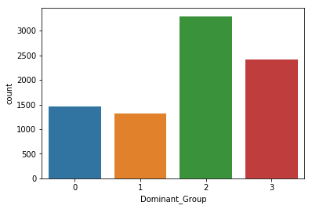

```python
import seaborn as sns
sns.countplot(x=df_final['Dominant_Group'], data = df_final)
```

[output not shown]

Summary " Here we can see the distrubution of documents based on the new assignment groups. Still unbalanced but still much better as compared to the original one . Also the document counts per groups have decenet number of observations based on which we can train the model and get some meaningful model

### Now we can just assume that we have the above dataset which has been processes in a decent way.

### Before proceeding for Deep learning model, we 'll try various machine learning algorithm to create and evaluate model.

Consistency in model scores (accuracy , precision, recall, F1-score, ROC AUC Score) will give us the confidence that our model can be generalised and will work in production environment

#### Let us start with our X(features) and y(label) dataset

```python
X = df_final['Clean_text']
y = df_final['Dominant_Group']
```

```python
# Split into training and testing datasets

from sklearn.model_selection import train_test_split
X_train, X_test, y_train, y_test = train_test_split(X,y, test_size=0.20, random_state=42)
```

```python
## Prepartion for visual creatin of accuracy scores
## Here we are creating a data frame
## We'll use it to store the summary of various algorithms  for classification
## We'll later use it to plot the comparison
log_cols = ["Classifier", "Accuracy","Precision-Score","Recall-Score","F1-Score","ROC_AUC_Score"]
log      = pd.DataFrame(columns=log_cols)
```

```python
## Another preparion work
## Well be using this function to plot the confusion matrix (for better visuaization)
import itertools
np.set_printoptions(precision=2);
class_names = ["Grp_0", "Grp_1", 'Grp_2',"Grp_3"]
#plt.figure(figsize=(7, 7))
#plt.grid(False)

def plot_confusion_matrix(cm, classes, title='Confusion matrix', cmap=plt.cm.Blues):
    """
    This function prints and plots the confusion matrix.
    """
    plt.imshow(cm, interpolation='nearest', cmap=cmap)
    plt.title(title)
    tick_marks = np.arange(len(classes))
    plt.xticks(tick_marks, classes, rotation=0)
    plt.yticks(tick_marks, classes)

    name = None
    fmt = 'd'
    thresh = cm.max() / 2
    # i and j tell us the coordinates of boxes
    for i, j in itertools.product(range(cm.shape[0]), range(cm.shape[1])):
        name = ""

        plt.text(j, i, format(cm[i, j], fmt) + "\n" + name, horizontalalignment="center",
                 fontsize=10, color="white" if cm[i, j] > thresh else "black")

    plt.tight_layout()
    plt.ylabel('True label')
    plt.xlabel('Predicted label')
    plt.show()
```

As we have mentioned previously, we cannot use text as it is for model building, we will have to extract features from the text We'll do it by creating vectors / features using CounterVectorizer.

```python
from sklearn.feature_extraction.text import CountVectorizer

vectorizer = CountVectorizer()
X_train_bow = vectorizer.fit_transform(X_train)
X_test_bow = vectorizer.transform(X_test)
```

```python
## Let us see if we get the desired result
X_train_bow.toarray()
## yes, it looks good
```

```
array([[0, 0, 0, ..., 0, 0, 0],
       [0, 0, 0, ..., 0, 0, 0],
       [0, 0, 0, ..., 0, 0, 0],
       ...,
       [0, 0, 0, ..., 0, 0, 0],
       [0, 0, 0, ..., 0, 0, 0],
       [0, 0, 0, ..., 0, 0, 0]], dtype=int64)
```

Here we create some function to transforrm, create and store model scores for different algorithms in a dataframe

```python
def multiclass_roc_auc_score(y_test, y_pred, average="macro"):
    lb = LabelBinarizer()
    lb.fit(y_test)
    y_test = lb.transform(y_test)
    y_pred = lb.transform(y_pred)
    return roc_auc_score(y_test, y_pred, average=average)
```

```python
def evaluate_model_score(clf,y_test,y_pred,log,columns = log_cols):
    accuracy      = metrics.accuracy_score(y_test,y_pred)
    precision     = metrics.precision_score(y_test,y_pred,average='macro')
    recall        = metrics.recall_score(y_test,y_pred,average='macro')
    f1_score      = metrics.f1_score(y_test,y_pred,average='macro')
    roc_auc_score = multiclass_roc_auc_score(y_test, y_pred)
    log_entry     = pd.DataFrame([[clf,accuracy,precision,recall,f1_score,roc_auc_score]], columns=log_cols)
    log = log.append(log_entry)
    return(log)
```

Now comes the model creation from different algorithms. we are using the following classifiers:

- Logistic Regression
- Decision Tree
- Random Forest
- AdaBoost
- Gradient Boost
- Multinomial Naive Bayes
- Support Vector Classifier

We have done hyperparameter tuning for decision tree and SVC using RandomizedSearchVC and GridSearchCV (See later , code commented)

```python
clf = LogisticRegression()
clf.fit(X_train_bow, y_train)
y_pred = clf.predict(X_test_bow)
lr_cnf_matrix    = metrics.confusion_matrix(y_test, y_pred)
clf_name ="Bow Logistic Classifier"
log=evaluate_model_score(clf_name,y_test,y_pred, log,columns = log_cols)

clf = DecisionTreeClassifier(criterion = 'entropy' )
clf.fit(X_train_bow, y_train)
dt_cnf_matrix    = metrics.confusion_matrix(y_test, y_pred)
y_pred = clf.predict(X_test_bow)
clf_name ="Bow Decision Tree"
log=evaluate_model_score(clf_name,y_test,y_pred, log,columns = log_cols)

clf = RandomForestClassifier()
clf.fit(X_train_bow, y_train)
y_pred = clf.predict(X_test_bow)
rf_cnf_matrix    = metrics.confusion_matrix(y_test, y_pred)
clf_name ="Bow Random Forest"
log=evaluate_model_score(clf_name,y_test,y_pred, log,columns = log_cols)

clf = AdaBoostClassifier(n_estimators= 50)
clf.fit(X_train_bow, y_train)
ab_cnf_matrix    = metrics.confusion_matrix(y_test, y_pred)
y_pred = clf.predict(X_test_bow)
clf_name ="Bow AdaBoost"
log=evaluate_model_score(clf_name,y_test,y_pred, log,columns = log_cols)

clf = GradientBoostingClassifier()
clf.fit(X_train_bow, y_train)
y_pred = clf.predict(X_test_bow)
gb_cnf_matrix    = metrics.confusion_matrix(y_test, y_pred)
clf_name ="Bow Gradient Boosting"
log=evaluate_model_score(clf_name,y_test,y_pred, log,columns = log_cols)

clf = MultinomialNB()
clf.fit(X_train_bow, y_train)
y_pred = clf.predict(X_test_bow)
nb_cnf_matrix    = metrics.confusion_matrix(y_test, y_pred)
clf_name ="Bow Multinomial Naive Bayes"
log=evaluate_model_score(clf_name,y_test,y_pred, log,columns = log_cols)


best_model_svm = svm.SVC(C=1, kernel = 'linear', gamma = 'auto')
best_model_svm.fit(X_train_bow,y_train)
svc_cnf_matrix    = metrics.confusion_matrix(y_test, y_pred)
y_pred = best_model_svm.predict(X_test_bow)
clf_name ="Bow Best Param SVC "
log=evaluate_model_score(clf_name,y_test,y_pred, log,columns = log_cols)
```

```python
## Now Cross validation using Grid Search  C values - 0.01, 0.05, 0.5, 1 and kernel = linear, rbf)
# and find out the best hyper parameters and do cross validation to find the accuracy

#from sklearn.model_selection import GridSearchCV
#from sklearn.model_selection import cross_val_score
#model_cv_svm = svm.SVC()
#params = {'C': [0.01,0.1,0.5,1], 'kernel': ['linear','rbf'], 'gamma': ['auto','scale']}
#model_1 = GridSearchCV(model_cv_svm, param_grid=params, cv=10)
#model_1.fit(X_train_bow,y_train)

#print("Best Hyper parameters: \n ", model_1.best_params_)
#print(" Best cross-validation accuracy: {:.2f}". format( model_1.best_score_))
#print(" Test set accuracy: {:.2f}". format( model_1.score(X_test_bow, y_test)))

#Best Hyper parameters:

#Best Hyper parameters:
#  {'C': 1, 'gamma': 'auto', 'kernel': 'linear'}
# Best cross-validation accuracy: 0.90
```

Best Hyper parameters: {'C': 1, 'gamma': 'auto', 'kernel': 'liner'} Best cross-validation accuracy: 0.90

```python
## Import Libraries for Randomized Search Cross Validation
#from sklearn.model_selection import RandomizedSearchCV
#from scipy.stats import randint
## We start a satndard instantiation using DEFAULT parameters
#dt_init = DecisionTreeClassifier()

# Now I create parameters which I want Randomized Search to peform parameter tuning
#param_dist = {"max_depth":[5,None],
#              "min_samples_leaf": randint(1,3),
#              "max_features":randint(1,3),
#              "criterion": ['gini','entropy']
#             }

## Here I pass the parameters to Randomized Search
#dt_opt = RandomizedSearchCV(dt_init,param_dist,cv=9)
#dt_opt.fit(X_train_bow,y_train)
## Here the Randomized Search has done the work for me
## In case, I want to see the parameter ,(best parameters), we ca see them
#print("Tuned Decision Tree Parameters {} ".format(dt_opt.best_params_))
#print("Tuned Decision Accuracy Scores {} ".format(dt_opt.best_score_))

#Tuned Decision Tree Parameters {'criterion': 'entropy', 'max_depth': None, 'max_features': 2, 'min_samples_leaf': 1}
#Tuned Decision Accuracy Scores 0.7975857500368025
```

*NOW TIME TO SEE THE OUTPUT OF ALL EFFORTS WHICH WE HAVE PUT IT TILL NOW*

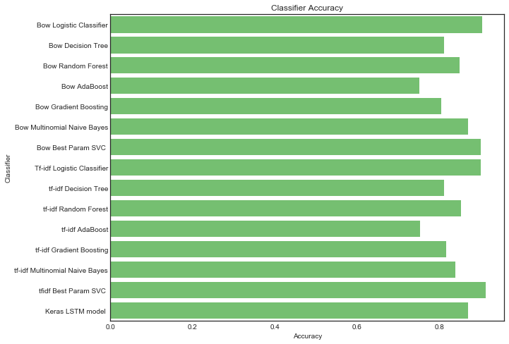

```python
## Comparing accuracy scores
## let us see them graphically
plt.style.use('seaborn-white')
plt.figure(figsize=(10,8))
plt.xlabel('Accuracy')
plt.title('Classifier Accuracy')
sns.set_color_codes("muted")
sns.barplot(x='Accuracy', y='Classifier', data=log, color="g")
plt.show()
```

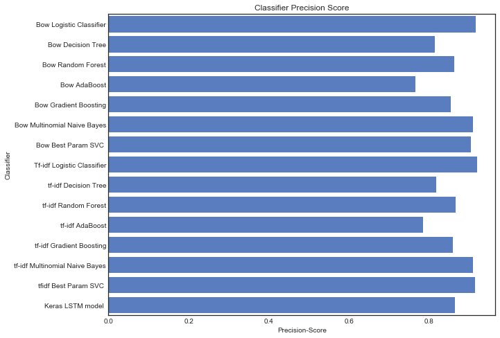

```python
plt.figure(figsize=(10,8))
plt.xlabel('Accuracy')
plt.title('Classifier Precision Score')
sns.set_color_codes("muted")
sns.barplot(x='Precision-Score', y='Classifier', data=log, color="b")
plt.show()
```

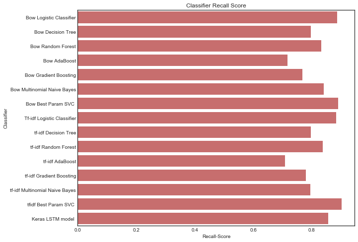

```python
plt.figure(figsize=(10,8))
plt.xlabel('Accuracy')
plt.title('Classifier Recall Score')
sns.set_color_codes("muted")
sns.barplot(x='Recall-Score', y='Classifier', data=log, color="r")
plt.show()
```

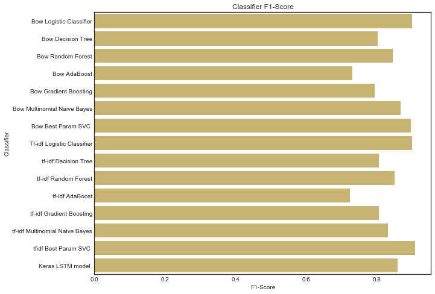

```python
plt.figure(figsize=(10,8))
plt.xlabel('Accuracy')
plt.title('Classifier F1-Score')
sns.set_color_codes("muted")
sns.barplot(x='F1-Score', y='Classifier', data=log, color="y")
plt.show()
```

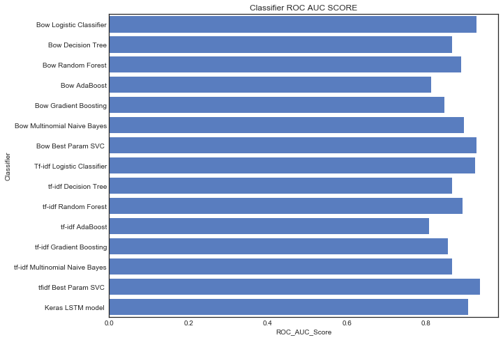

```python
plt.figure(figsize=(10,8))
plt.xlabel('ROC AUC SCORE')
plt.title('Classifier ROC AUC SCORE')
sns.set_color_codes("muted")
sns.barplot(x='ROC_AUC_Score', y='Classifier', data=log, color="b")
plt.show()
```

**Summary:**

This also sets up something like a bench mark which we should be looking for while using deep learning.

##### Let us have a look at the confusion matrix as well

```python
plt.style.use('seaborn-whitegrid')
```

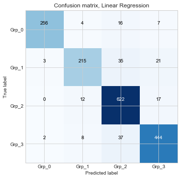

[figure not shown]

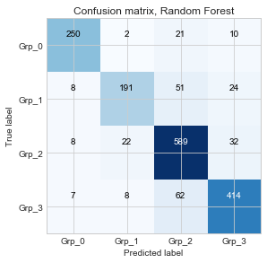

[figure not shown]

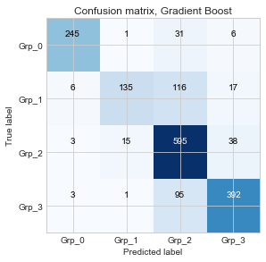

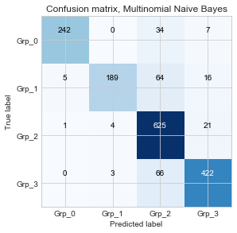

[figure not shown]

```python
plt.figure(figsize=(5,5))
plot_confusion_matrix(lr_cnf_matrix, classes=class_names, title='Confusion matrix, Linear Regression')
plot_confusion_matrix(dt_cnf_matrix, classes=class_names, title='Confusion matrix, Deision Tree')
plot_confusion_matrix(rf_cnf_matrix, classes=class_names, title='Confusion matrix, Random Forest')
plot_confusion_matrix(ab_cnf_matrix, classes=class_names, title='Confusion matrix, AdaBoost')
plot_confusion_matrix(gb_cnf_matrix, classes=class_names, title='Confusion matrix, Gradient Boost')
plot_confusion_matrix(nb_cnf_matrix, classes=class_names, title='Confusion matrix, Multinomial Naive Bayes')
plot_confusion_matrix(gb_cnf_matrix, classes=class_names, title='Confusion matrix, Support Vecctor Classifier')
```

```python
from sklearn.feature_extraction.text import TfidfTransformer

tfidf_transformer = TfidfTransformer()
X_train_tfidf = tfidf_transformer.fit_transform(X_train_bow)
X_test_tfidf  = tfidf_transformer.transform(X_test_bow)
```

```python
clf = LogisticRegression()
clf.fit(X_train_tfidf, y_train)
y_pred = clf.predict(X_test_tfidf)
lr_cnf_matrix    = metrics.confusion_matrix(y_test, y_pred)
clf_name ="Tf-idf Logistic Classifier"
log=evaluate_model_score(clf_name,y_test,y_pred, log,columns = log_cols)

clf = DecisionTreeClassifier(criterion = 'entropy' )
clf.fit(X_train_tfidf, y_train)
dt_cnf_matrix    = metrics.confusion_matrix(y_test, y_pred)
y_pred = clf.predict(X_test_tfidf)
clf_name ="tf-idf Decision Tree"
log=evaluate_model_score(clf_name,y_test,y_pred, log,columns = log_cols)

clf = RandomForestClassifier()
clf.fit(X_train_tfidf, y_train)
y_pred = clf.predict(X_test_tfidf)
rf_cnf_matrix    = metrics.confusion_matrix(y_test, y_pred)
clf_name ="tf-idf Random Forest"
log=evaluate_model_score(clf_name,y_test,y_pred, log,columns = log_cols)

clf = AdaBoostClassifier(n_estimators= 50)
clf.fit(X_train_tfidf, y_train)
ab_cnf_matrix    = metrics.confusion_matrix(y_test, y_pred)
y_pred = clf.predict(X_test_tfidf)
clf_name ="tf-idf AdaBoost"
log=evaluate_model_score(clf_name,y_test,y_pred, log,columns = log_cols)

clf = GradientBoostingClassifier()
clf.fit(X_train_tfidf, y_train)
y_pred = clf.predict(X_test_tfidf)
gb_cnf_matrix    = metrics.confusion_matrix(y_test, y_pred)
clf_name ="tf-idf Gradient Boosting"
log=evaluate_model_score(clf_name,y_test,y_pred, log,columns = log_cols)

clf = MultinomialNB()
clf.fit(X_train_tfidf, y_train)
y_pred = clf.predict(X_test_tfidf)
nb_cnf_matrix    = metrics.confusion_matrix(y_test, y_pred)
clf_name ="tf-idf Multinomial Naive Bayes"
log=evaluate_model_score(clf_name,y_test,y_pred, log,columns = log_cols)


best_model_svm = svm.SVC(C=1, kernel = 'linear', gamma = 'auto')
best_model_svm.fit(X_train_tfidf,y_train)
svc_cnf_matrix    = metrics.confusion_matrix(y_test, y_pred)
y_pred = best_model_svm.predict(X_test_tfidf)
clf_name ="tfidf Best Param SVC "
log=evaluate_model_score(clf_name,y_test,y_pred, log,columns = log_cols)
```

```python
X_test_tfidf.toarray()
```

```
array([[0., 0., 0., ..., 0., 0., 0.],
       [0., 0., 0., ..., 0., 0., 0.],
       [0., 0., 0., ..., 0., 0., 0.],
       ...,
       [0., 0., 0., ..., 0., 0., 0.],
       [0., 0., 0., ..., 0., 0., 0.],
       [0., 0., 0., ..., 0., 0., 0.]])
```

As we can see that the data has already in the lowercase form.

So we just need to clean the data, tokenize it, and then do lemmatization process.

## NOW WE WILL START PREPARATION WORK FOR OUR MODEL BUILDING**

### Import required modules required for project modelling

### Set Different Parameters for the model

```python
df_final['length'] = df_final['Clean_text'].apply(lambda x: len(x.split(" ")))
print("Maximum Length among the lines : " ,max(df_final['length']))
# Let us see if we could do it correctly .Looks good
df_final.head()
```

```
Maximum Length among the lines :  22
```

|  | Document_No | Dominant_Group | Clean_text | Assignment group | length |
| --- | --- | --- | --- | --- | --- |
| 0 | 0 | 2 | login issue | GRP_0 | 3 |
| 1 | 1 | 2 | outlook | GRP_0 | 2 |
| 2 | 2 | 2 | cant log vpn | GRP_0 | 4 |
| 3 | 3 | 2 | unable access hr_tool page | GRP_0 | 5 |
| 4 | 4 | 2 | skype error | GRP_0 | 3 |

```python
## Define parameters

max_features = 6000
maxlen = 25
embedding_size = 200
```

```python
tokenizer = Tokenizer(num_words=max_features)
tokenizer.fit_on_texts(list(df_final['Clean_text']))
```

```python
sequence = tokenizer.texts_to_sequences(df_final['Clean_text'])
X = pad_sequences(sequence, maxlen = maxlen, padding='post') # parameter padding = 'post' padd zeros in the last
y = pd.get_dummies(df_final['Dominant_Group'])
X_train,X_test,y_train,y_test = train_test_split(X,y,test_size=0.20, random_state = 42)
```

```python
print("Number of Samples:", len(X))
print("Number of Labels: ", len(y))
print("Training set samples: ", len(X_train))
print("Test     set samples: ", len(X_test))
```

```
Number of Samples: 8492
Number of Labels:  8492
Training set samples:  6793
Test     set samples:  1699
```

```python
word_index = tokenizer.word_index
vocab_size = len(word_index)+1
print("My vocabulary size = ",vocab_size)
```

```
My vocabulary size =  5295
```

### Get the Word Embeddings using Embedding file as given below.

```python
EMBEDDING_FILE = 'glove.6B.200d.txt'
embeddings = {}
for o in open(EMBEDDING_FILE,encoding="utf8"):
    word = o.split(" ")[0]
    # print(word)
    embd = o.split(" ")[1:]
    embd = np.asarray(embd, dtype='float32')
    # print(embd)
    embeddings[word] = embd

print("No. of embeddings = ", len(embeddings))
```

```
No. of embeddings =  400000
```

```python
embedding_matrix = np.zeros((vocab_size, 200))

for word, i in tokenizer.word_index.items():
    embedding_vector = embeddings.get(word)
    if embedding_vector is not None:
        embedding_matrix[i] = embedding_vector
len(embedding_matrix)
```

```
5295
```

```python
from keras.layers import LSTM, Activation, Dense, Dropout, Input, Embedding
from keras.optimizers import RMSprop
from keras.models import Sequential
from keras.layers import Dense, Embedding, LSTM, SpatialDropout1D,Bidirectional,Flatten,TimeDistributed
from keras.layers import GlobalMaxPool1D,GlobalAveragePooling1D

#embedding_size = 300


model = Sequential()
model.add(Embedding(vocab_size, embedding_size, weights = [embedding_matrix], trainable = False))
model.add(SpatialDropout1D(0.4))
model.add(Bidirectional(LSTM(100, return_sequences = True,recurrent_dropout=0.1, dropout=0.1)))
model.add(GlobalMaxPool1D())
model.add(Dense(128, activation="relu"))
model.add(Dropout(0.5))
model.add(Dense(64, activation="relu"))
model.add(Dropout(0.5))
model.add(Dense(32, activation="relu"))
model.add(Dropout(0.5))

model.add(Dense(4, activation="softmax"))


model.compile(loss = 'categorical_crossentropy', optimizer='adam',metrics = ['accuracy'])
print("\n Here is the model summary ")
print("==========================")
print(model.summary())
```

[output not shown]

[output not shown]

[output not shown]

[output not shown]

[output not shown]

[output not shown]

[output not shown]

[output not shown]

[output not shown]

[output not shown]

[output not shown]

[output not shown]

[output not shown]

[output not shown]

```
 Here is the model summary
==========================
_________________________________________________________________
Layer (type)                 Output Shape              Param #
=================================================================
embedding_1 (Embedding)      (None, None, 200)         1059000
_________________________________________________________________
spatial_dropout1d_1 (Spatial (None, None, 200)         0
_________________________________________________________________
bidirectional_1 (Bidirection (None, None, 200)         240800
_________________________________________________________________
global_max_pooling1d_1 (Glob (None, 200)               0
_________________________________________________________________
dense_1 (Dense)              (None, 128)               25728
_________________________________________________________________
dropout_1 (Dropout)          (None, 128)               0
_________________________________________________________________
dense_2 (Dense)              (None, 64)                8256
_________________________________________________________________
dropout_2 (Dropout)          (None, 64)                0
_________________________________________________________________
dense_3 (Dense)              (None, 32)                2080
_________________________________________________________________
dropout_3 (Dropout)          (None, 32)                0
_________________________________________________________________
dense_4 (Dense)              (None, 4)                 132
=================================================================
Total params: 1,335,996
Trainable params: 276,996
Non-trainable params: 1,059,000
_________________________________________________________________
None
```

```python
epoch = 25
batch_size = 100
history = model.fit(X_train, y_train, epochs = epoch, batch_size=batch_size,validation_split=0.20,verbose = 1)
```

[output not shown]

[output not shown]

```
Train on 5434 samples, validate on 1359 samples
```

```python
import pickle
model_filename = 'model_capstone.pkl'
tokenizer_filename = 'tokenizer_capstone.pkl'

pickle.dump(model, open(model_filename, 'wb'))
pickle.dump(tokenizer, open(tokenizer_filename, 'wb'))
```

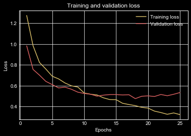

```python
plt.style.use('dark_background')

loss = history.history['loss']
val_loss = history.history['val_loss']
epochs = range(1, len(loss) + 1)
plt.plot(epochs, loss, 'y', label='Training loss')
plt.plot(epochs, val_loss, 'r', label='Validation loss')
plt.title('Training and validation loss')
plt.xlabel('Epochs')
plt.ylabel('Loss')
plt.legend()
plt.show()
```

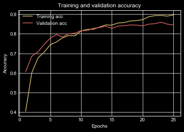

```python
acc = history.history['acc']
val_acc = history.history['val_acc']
plt.plot(epochs, acc, 'y', label='Training acc')
plt.plot(epochs, val_acc, 'r', label='Validation acc')
plt.title('Training and validation accuracy')
plt.xlabel('Epochs')
plt.ylabel('Accuracy')
plt.legend()
plt.show()
```

```python
y_test1=np.argmax(y_test.values,axis=1)
y_pred=model.predict_classes(X_test)
```

```python
clf_name ="Keras LSTM model "
log=evaluate_model_score(clf_name,y_test1,y_pred, log,columns = log_cols)
```

```python
display(log)
```

|  | Classifier | Accuracy | Precision-Score | Recall-Score | F1-Score | ROC_AUC_Score |
| --- | --- | --- | --- | --- | --- | --- |
| 0 | Bow Logistic Classifier | 0.904650 | 0.916114 | 0.887249 | 0.899885 | 0.925925 |
| 0 | Bow Decision Tree | 0.811654 | 0.814121 | 0.796554 | 0.802476 | 0.864319 |
| 0 | Bow Random Forest | 0.849912 | 0.862354 | 0.832103 | 0.844493 | 0.888402 |
| 0 | Bow AdaBoost | 0.751619 | 0.765275 | 0.717153 | 0.729426 | 0.812173 |
| 0 | Bow Gradient Boosting | 0.804591 | 0.854420 | 0.767694 | 0.792862 | 0.846120 |
| 0 | Bow Multinomial Naive Bayes | 0.869923 | 0.909453 | 0.841109 | 0.866430 | 0.895297 |
| 0 | Bow Best Param SVC | 0.901707 | 0.902875 | 0.889851 | 0.895659 | 0.927222 |
| 0 | Tf-idf Logistic Classifier | 0.901118 | 0.919071 | 0.882716 | 0.898334 | 0.922676 |
| 0 | tf-idf Decision Tree | 0.811065 | 0.817551 | 0.797523 | 0.805758 | 0.864453 |
| 0 | tf-idf Random Forest | 0.853443 | 0.865516 | 0.837152 | 0.848915 | 0.891519 |
| 0 | tf-idf AdaBoost | 0.752796 | 0.784005 | 0.707682 | 0.723310 | 0.806857 |
| 0 | tf-idf Gradient Boosting | 0.817540 | 0.859579 | 0.780286 | 0.804414 | 0.855040 |
| 0 | tf-idf Multinomial Naive Bayes | 0.838729 | 0.908467 | 0.795226 | 0.830068 | 0.865578 |
| 0 | tfidf Best Param SVC | 0.912890 | 0.913908 | 0.901683 | 0.907394 | 0.935187 |
| 0 | Keras LSTM model | 0.869335 | 0.864070 | 0.855301 | 0.858307 | 0.904723 |
| 0 | Keras LSTM model | 0.869335 | 0.864070 | 0.855301 | 0.858307 | 0.904723 |

```python
def model_predict(text):
    model1 = pickle.load(open('model.pkl', 'rb'))
    tokenizer1 = pickle.load(open('tokenizer.pkl', 'rb'))
    document=[text]
    documents=preprocess_text(document)
    sequence = tokenizer1.texts_to_sequences(documents)
    X = pad_sequences(sequence, maxlen = maxlen, padding='post',truncating='post')
    y=model1.predict_classes(X)

    return(y)
```

```python
pred_group = model_predict("special class failure printer is not a issue")
print("Predicted assignment group is : ", pred_group)
# model_predict("outlook issue")
#model_predict("job scheduelr")
```

```
Predicted assignment group is :  [2]
```